# VNO Atlas Figure 4

Max Hills

27 June, 2024

> This file contains statistics and figures from the paper, “Molecular, Cellular, and Developmental Organization of the Mouse Vomeronasal organ at Single Cell Resolution” by Max Hills Jr., Limei Ma, Ai Fang, Thelma Chiremba, Seth Malloy, Allison Scott, Anoja Perera, and C. Ron Yu.

The paper can be found here:

[Molecular, Cellular, and Developmental Organization of the Mouse Vomeronasal organ at Single Cell Resolution](https://elifesciences.org/reviewed-preprints/97356#tab-content)

# Receptor expression in the VNO

## Expression level of individual receptors (total raw counts) plotted against the number of cells expressing the receptor for V1R, V2R, VNO-Olfr, and MOE-Olfr

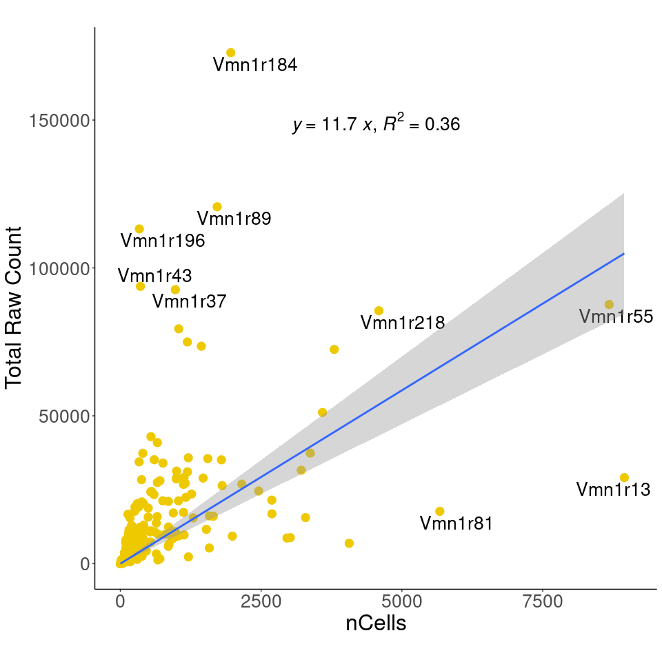

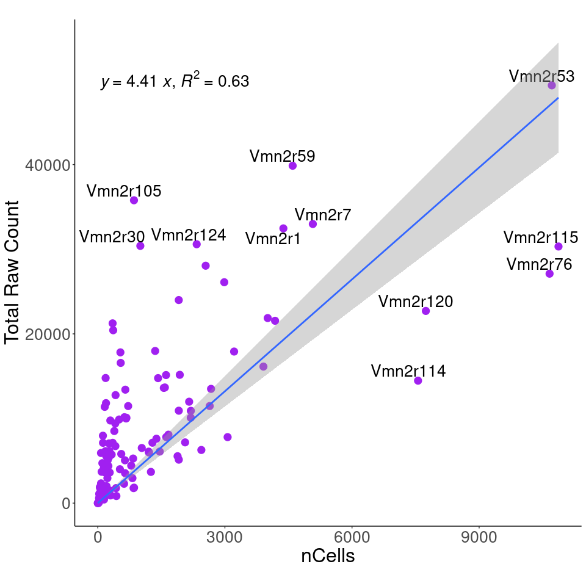

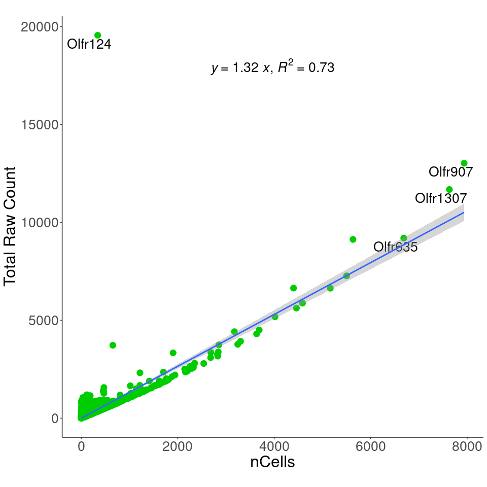

Main Olfactory Epithelium - Olfrs

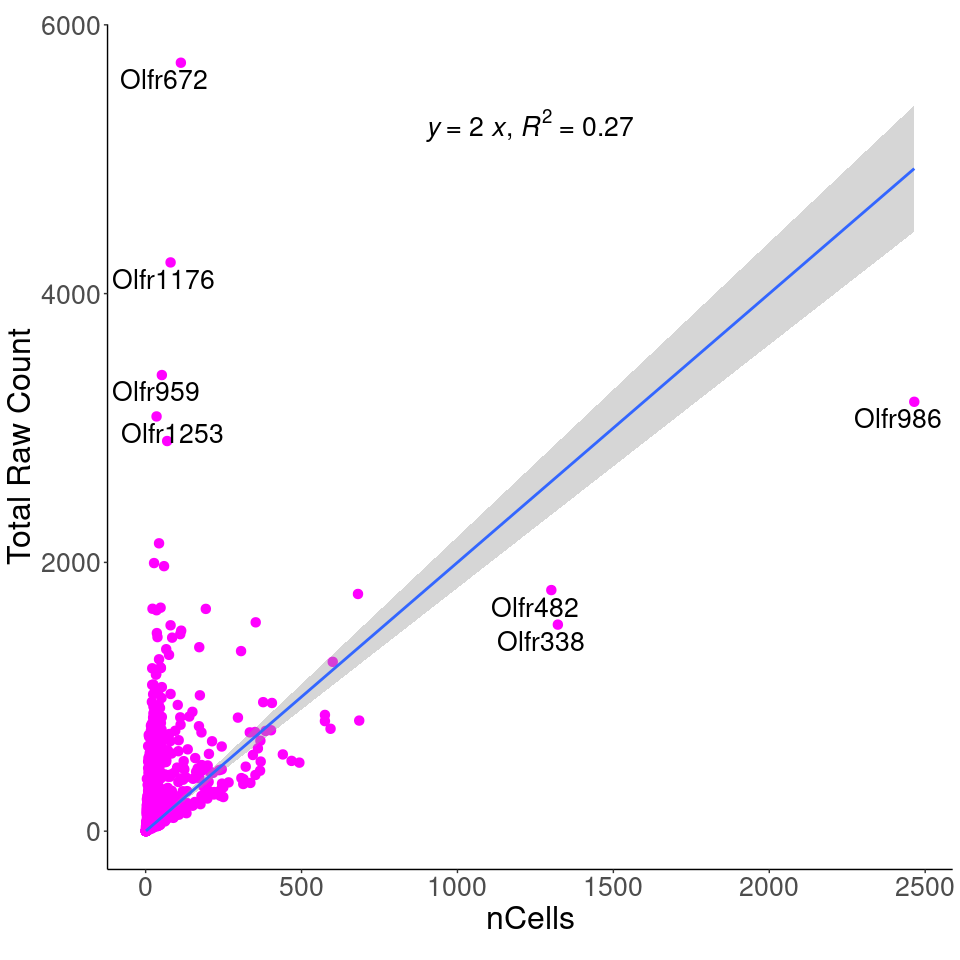

## Ranked distribution of average expression per cell for the four receptor classes. Pie charts show the number of cells expressing a receptor at the specified range

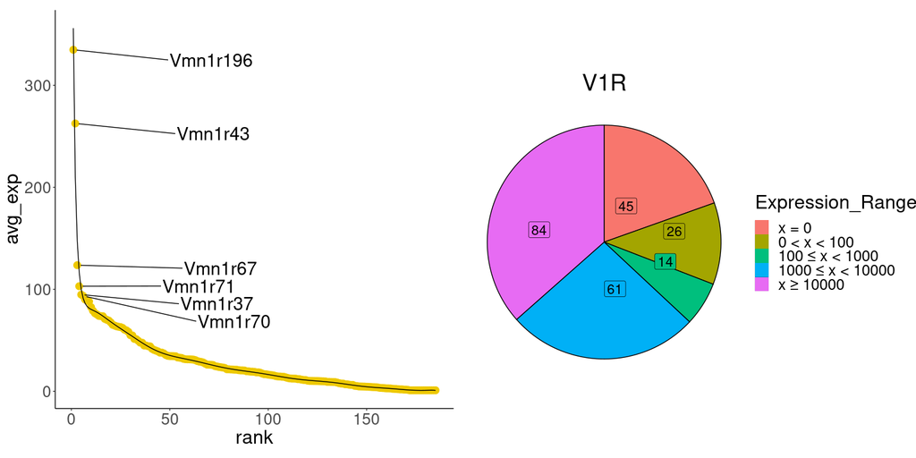

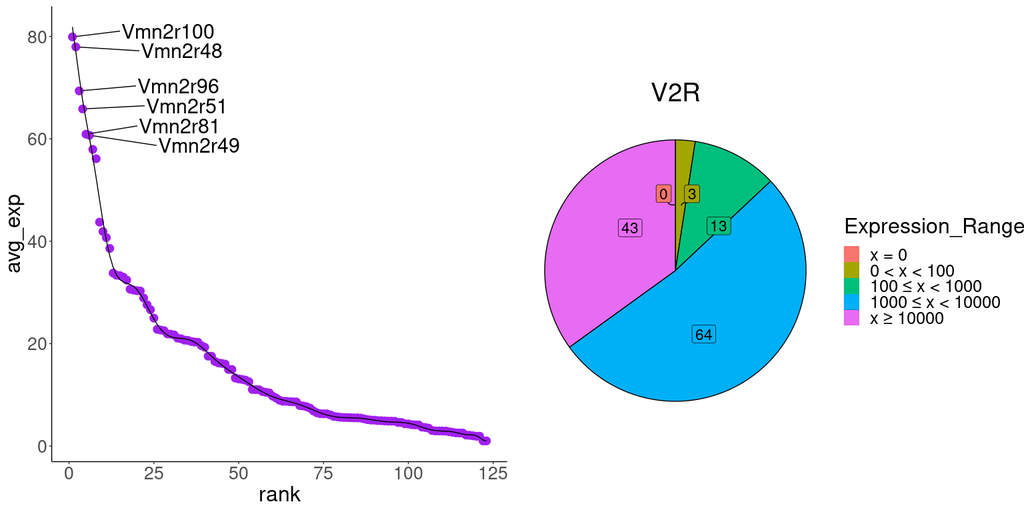

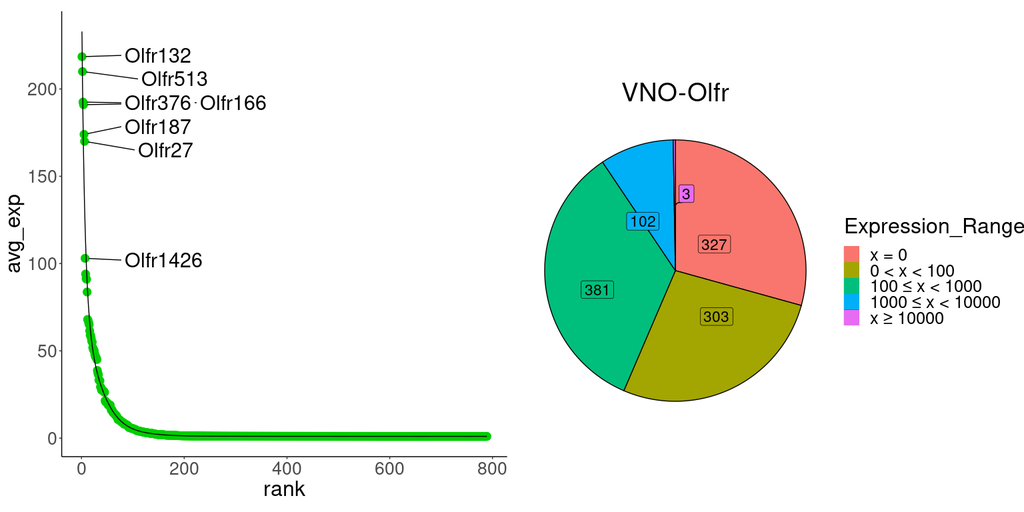

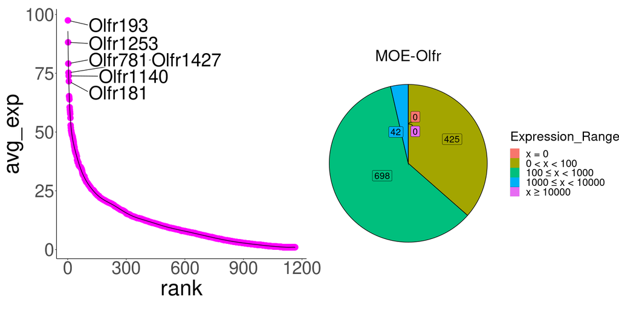

## Receptor distributions with **pseudogenes included**

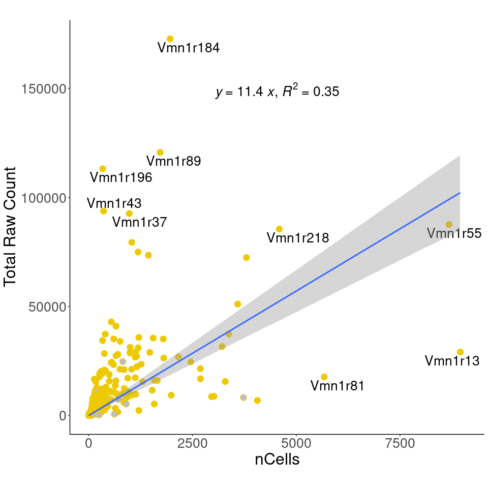

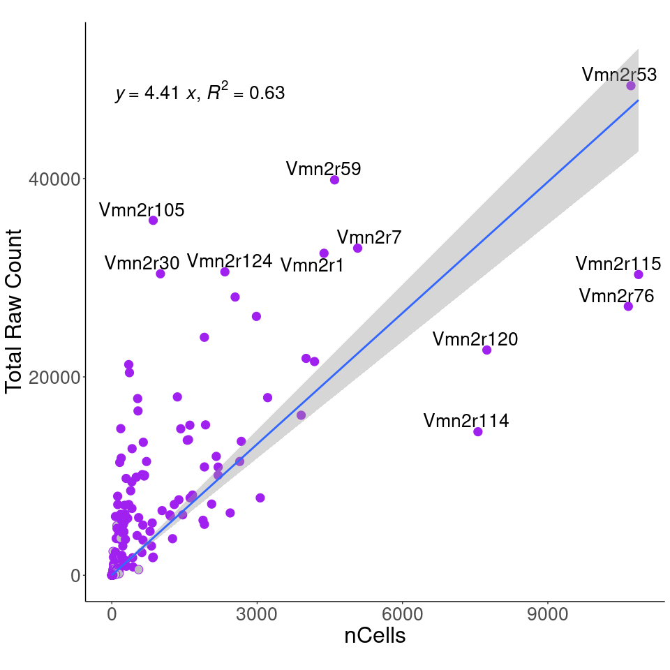

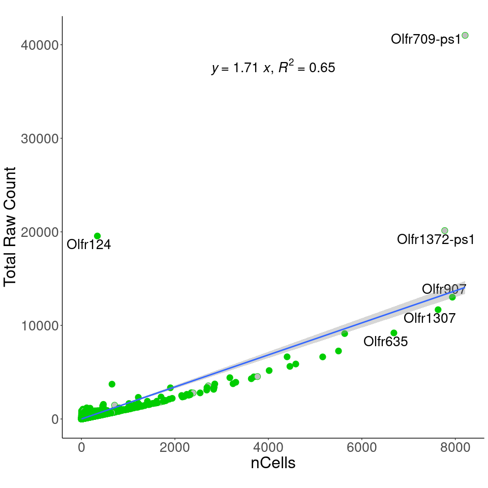

## Rank by average count distributions for V1R, V2R, and VSN-OR, **pseudogenes included**

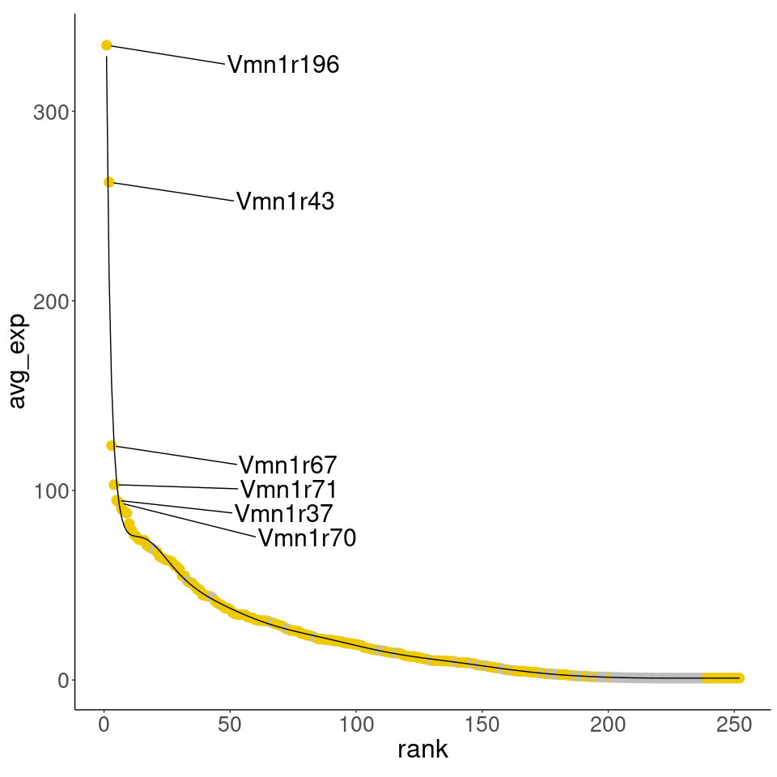

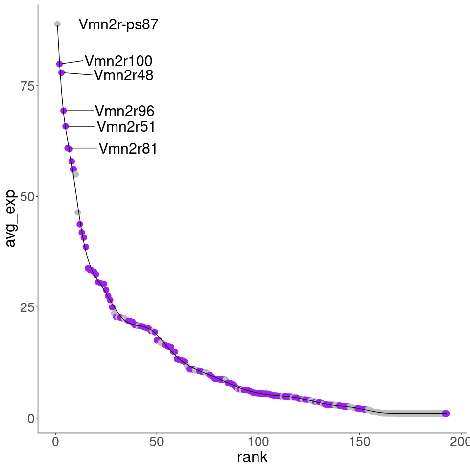

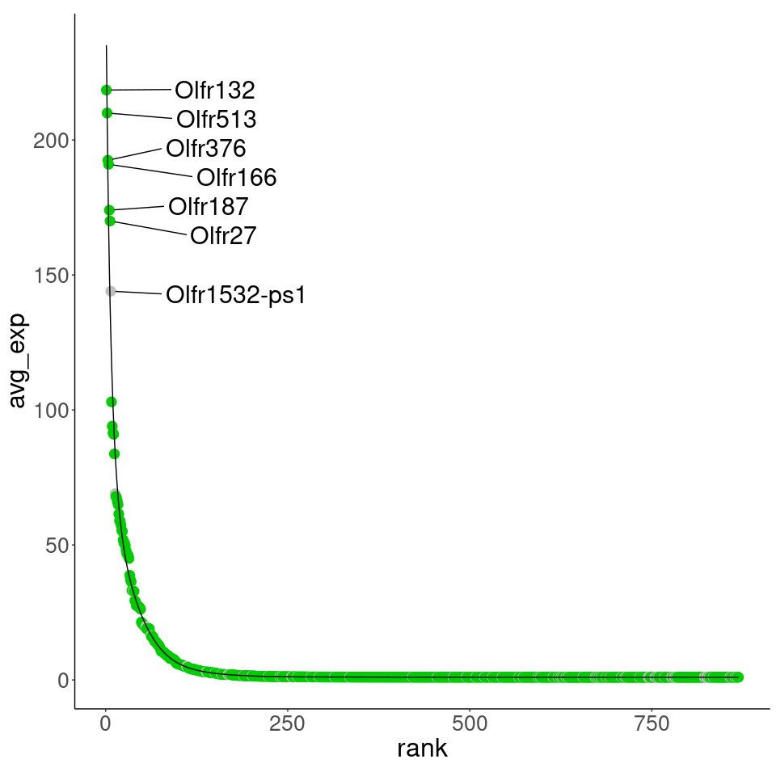

## Heatmaps showing the correlation of transcription factor expression among the V1Rs or V2Rs

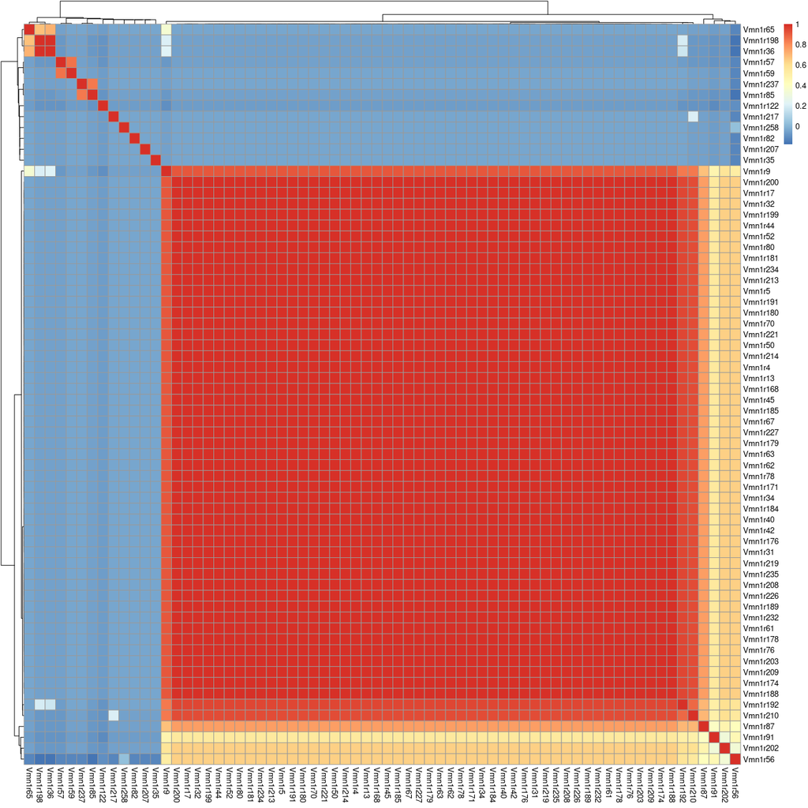

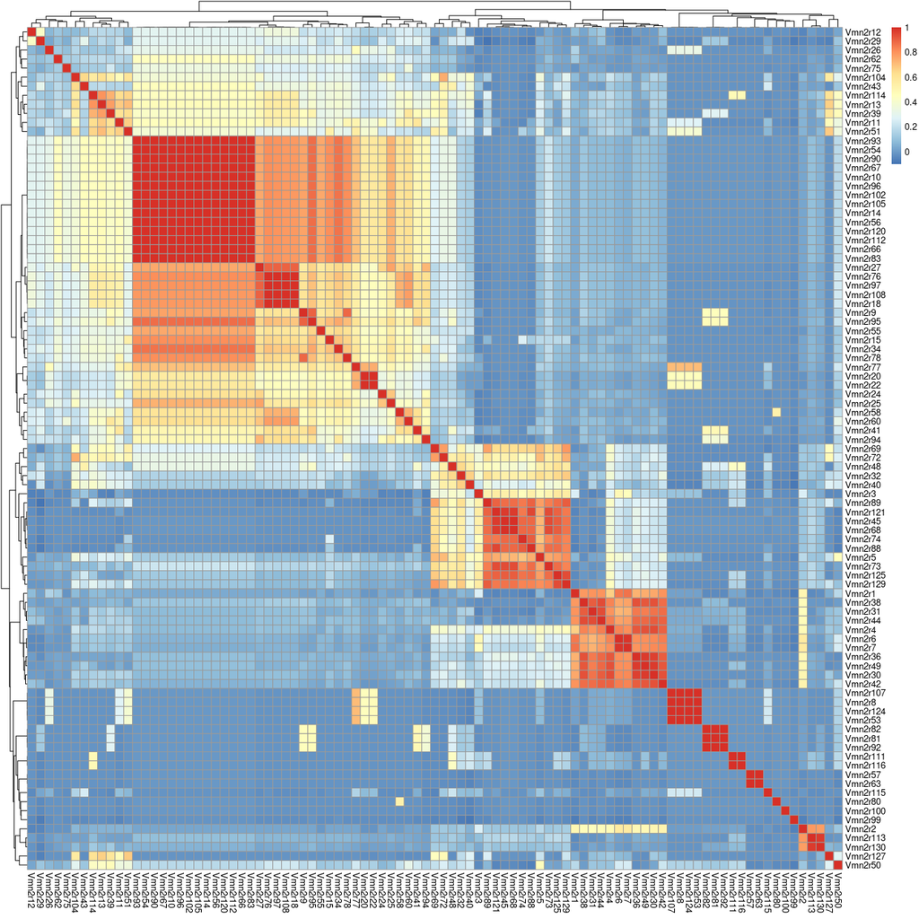

## Distribution density plot showing relationship between similarity of transcription factor (TF) gene expression profiles and receptor sequence similarity

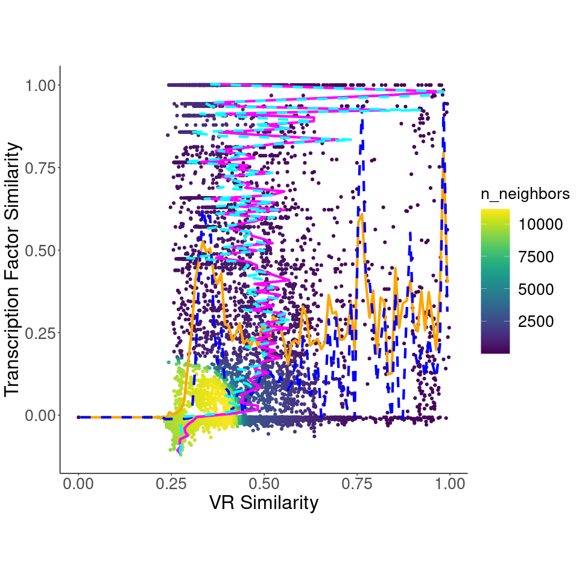

## Heatmaps showing V1R-TF and V2R-TF associations. Heat shows average expression level for TF genes for a given receptor type

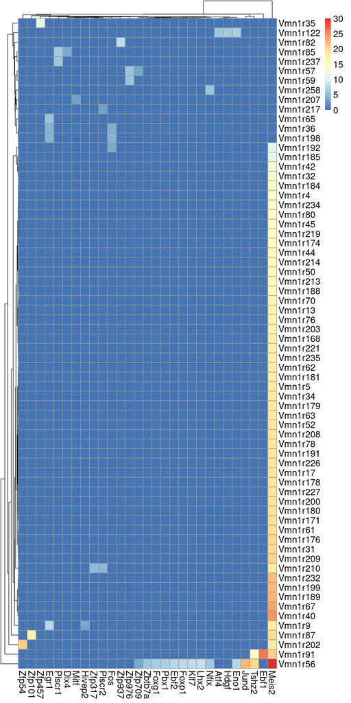

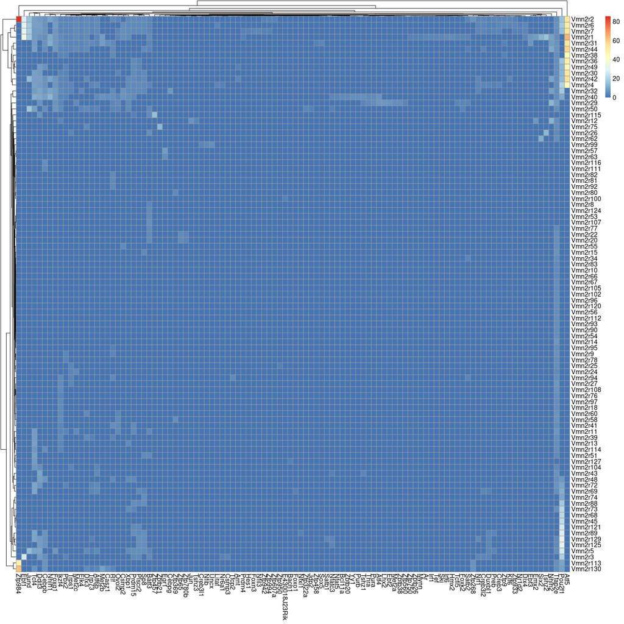